# HW 1: OLS Review

Advanced Regression (STAT 353-0)

Author

Alejandro ABISAMBRA

Published

January 16, 2025

**Github Repo Link**

To link to your github **repo**sitory, appropriately edit the example link below. Meaning replace `https://your-github-repo-url` with your github repo url. Suggest verifying the link works before submitting.

https://github.com/aac-abis/HW1_Abisambra

## Overview

In this homework, you will review OLS regression. The concepts focused on here are obviously not all of what you know (from STAT 350), but they are concepts that are particularly important for this course. Pay particular attention to interpretation.

## Data

For this assignment, we are using the `Duncan` dataset. This dataset provides data on the prestige and other characteristics of 45 U. S. occupations in 1950. The data was collected by the sociologist [Otis Dudley Duncan](https://en.wikipedia.org/wiki/Otis_Dudley_Duncan).

## Preliminaries

As a first step, we load the `{car}` package. This is the package developed by the author of our textbook and contains several useful functions and datasets, so we will be using it throughout this quarter.

Begin by examining the first few rows of the `Duncan` data:

```r
library("car") # load car and carData packages
library(tidyverse)
library(stargazer)
```

```r
head(Duncan, n=10)
```

```
           type income education prestige
accountant prof     62        86       82
pilot      prof     72        76       83
architect  prof     75        92       90
author     prof     55        90       76
chemist    prof     64        86       90
minister   prof     21        84       87
professor  prof     64        93       93
dentist    prof     80       100       90
reporter     wc     67        87       52
engineer   prof     72        86       88
```

```r
dim(Duncan)
```

```
[1] 45  4
```

Obtain summary statistics for the variables in `Duncan`:

```r
summary(Duncan)
```

```
   type        income        education         prestige
 bc  :21   Min.   : 7.00   Min.   :  7.00   Min.   : 3.00
 prof:18   1st Qu.:21.00   1st Qu.: 26.00   1st Qu.:16.00
 wc  : 6   Median :42.00   Median : 45.00   Median :41.00
           Mean   :41.87   Mean   : 52.56   Mean   :47.69
           3rd Qu.:64.00   3rd Qu.: 84.00   3rd Qu.:81.00
           Max.   :81.00   Max.   :100.00   Max.   :97.00
```

As a first graph, we view a histogram of the variable `prestige`:

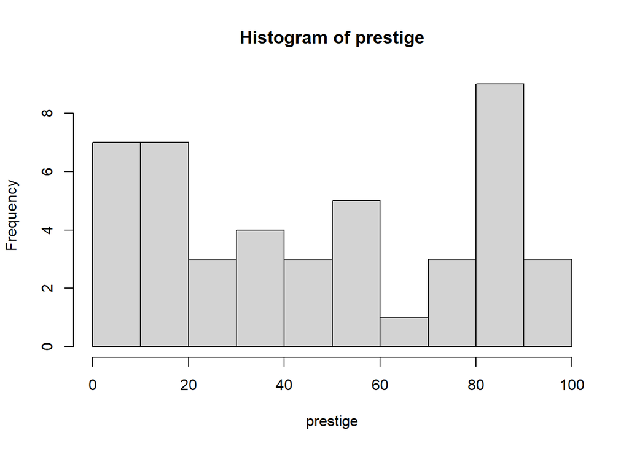

```r
with(Duncan, hist(prestige))
```

## Exercises

### 1. Examining the Data

A first step for any analysis should include Exploratory Data Analysis (EDA). This allows you to check to see that you understand the variables - how they are coded, if they are factors or continuous, and if there are mistakes.

**Solution**

First I will set the order of the “type” levels as follows:

bc (blue collar), wc (white collar), professional

as opposed to sorting them alphabetically. This will make the scatter plots easier to interpret.

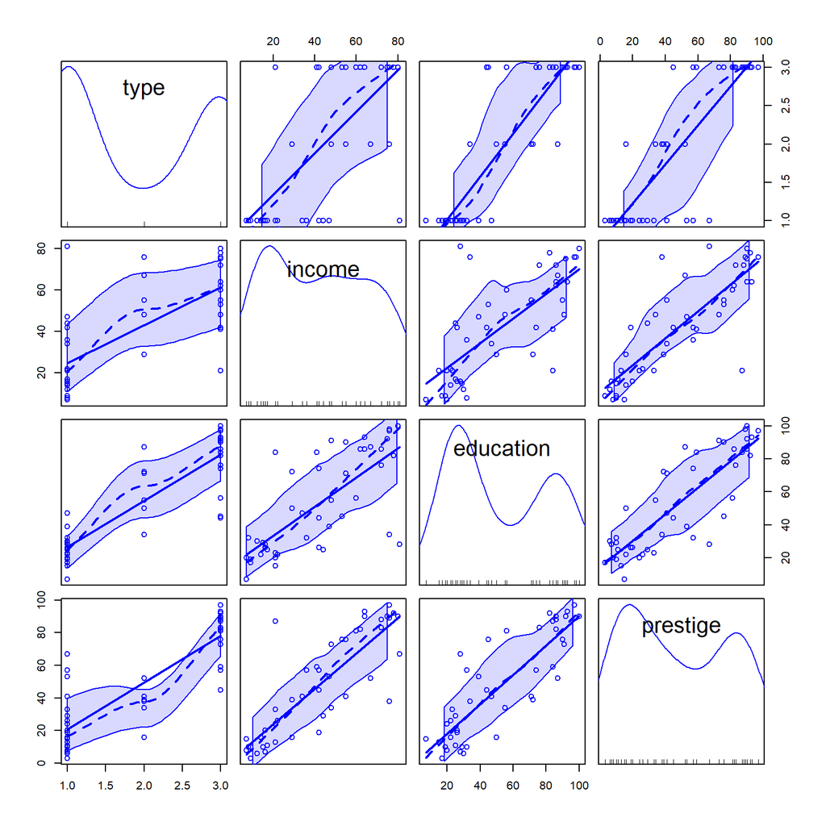

```r
duncan_data <- Duncan

duncan_data$type <- factor(duncan_data$type, levels = c("bc", "wc", "prof"))

scatterplotMatrix(duncan_data)
```

Via the scatterplots above - and any other EDA you’d like to do - describe the data. What seems to be going on here?

**Solution**

In addition to the scatterplots, I will construct a pairwise correlation table to assess the relationship between each pair of variables. (I will do this only for the continuous variables, of course).

```r
# Create data frame
duncan_cont_data <- duncan_data %>% select(-type)

# Compute the correlation matrix
cor_matrix <- cor(duncan_cont_data, use = "pairwise.complete.obs",
                  method = "pearson")

# Print the correlation table
print(cor_matrix)
```

```
             income education  prestige
income    1.0000000 0.7245124 0.8378014
education 0.7245124 1.0000000 0.8519156
prestige  0.8378014 0.8519156 1.0000000
```

**Based on the EDA, What seems to be going on?** The scatter plots above suggest a segmentation of the data for each variable that is increasing on most of the other variables. For example, education is increasing on both income and prestige. Higher levels of income (or prestige) are associated with higher levels of education. These relationships are corroborated by the pairwise correlation table above. The correlation table shows that the pairwise correlations are positive and large (>0.7) for the continuous variables.

With respect to the type of occupation (the only non-continuous variable), the relationship with the other variables also seems to be increasing. Taking the order of the categories as blue collar, white collar, prof, the scatter plots show that professional occupations are associated with the highest levels of income, prestige, and education, followed by white collar occupations and then lastly by blue collar occupations.

### 2. Regression Analysis

#### A. Model 1

Use the`lm()` function to fit a linear regression model to the data, in which `education` and `income` are regressed on `prestige`.

Interpret the findings from this model. Are education and income good explanations for an occupation’s prestige? Interpret the coefficient for income - what does it mean? Does education or income have a larger effect on prestige? Justify your conclusion.

**Solution**

```r
m1 <- lm(prestige ~ education + income, data = duncan_data)
summary(m1)
```

```
Call:
lm(formula = prestige ~ education + income, data = duncan_data)

Residuals:
    Min      1Q  Median      3Q     Max
-29.538  -6.417   0.655   6.605  34.641

Coefficients:
            Estimate Std. Error t value Pr(>|t|)
(Intercept) -6.06466    4.27194  -1.420    0.163
education    0.54583    0.09825   5.555 1.73e-06 ***
income       0.59873    0.11967   5.003 1.05e-05 ***
---
Signif. codes:  0 '***' 0.001 '**' 0.01 '*' 0.05 '.' 0.1 ' ' 1

Residual standard error: 13.37 on 42 degrees of freedom
Multiple R-squared:  0.8282,    Adjusted R-squared:   0.82
F-statistic: 101.2 on 2 and 42 DF,  p-value: < 2.2e-16
```

Both of the coefficients for education and income are statistically significant, with their respective p-values being well-below 0.001 (p < 0.001). In addition, the p-value for the F-Statistic for the model is also very small (p < 0.001), suggesting a general good fit of the model as a whole.

```r
deviance(m1)
```

```
[1] 7506.699
```

```r
pchisq(deviance(m1), m1$df.residual)
```

```
[1] 1
```

In addition, the residual deviance (and the p-value associated with the chi-squared distribution associated with the model’s deviance) shows that this specification performs similarly well to the saturated model. This in turn suggests that our current model is a good one, appropriately describing/fitting the variation in the data that we have.

Furthermore, the 2 covariates (education and income) explain a large amount of the variation found in the data for occupational prestige, which is reflected in the large R-Squared value of 0.82.

Because of the elements above, it appears that education and income provide a good model to describe the data patterns found in terms of educational prestige. However, all we have at this point are associations and not necessarily explanations (which in my view imply some sort of causal relationship).

A change of 1-unit of income is associated with an increase of 0.598 units of occupational prestige, and this coefficient is statistically significant, holding education constant.

On the other hand, a change of 1-unit of education (holding income constant) is associated with an increase of 0.545 units in occupational prestige.

As such, a change of 1-unit in income is associated with a larger change in prestige than a change in 1-unit of education. **However**, this comparison is not straightforward since the units of education and income may not be equivalent or equal. Standardizing these units (in terms of standard deviations, for example) would help in making these coefficients more readily comparable.

#### B. Model 2

Now, add in the `type` of occupation to the model. Is the model with `type` a better model? Explain what statistics you would use to make this decision, conduct the analysis, and interpret the results.

**Solution**

```r
m2 <- lm(prestige ~ education + income + type, data = duncan_data)
summary(m2)
```

```
Call:
lm(formula = prestige ~ education + income + type, data = duncan_data)

Residuals:
    Min      1Q  Median      3Q     Max
-14.890  -5.740  -1.754   5.442  28.972

Coefficients:
             Estimate Std. Error t value Pr(>|t|)
(Intercept)  -0.18503    3.71377  -0.050  0.96051
education     0.34532    0.11361   3.040  0.00416 **
income        0.59755    0.08936   6.687 5.12e-08 ***
typewc      -14.66113    6.10877  -2.400  0.02114 *
typeprof     16.65751    6.99301   2.382  0.02206 *
---
Signif. codes:  0 '***' 0.001 '**' 0.01 '*' 0.05 '.' 0.1 ' ' 1

Residual standard error: 9.744 on 40 degrees of freedom
Multiple R-squared:  0.9131,    Adjusted R-squared:  0.9044
F-statistic:   105 on 4 and 40 DF,  p-value: < 2.2e-16
```

To assess whether the second model (m2) is better than the previous one, I will use 3 statistics:

- The residual deviances of each model,
- The AIC statistic of each model,
- An ANOVA test to determine whether including “type” improves the model fit.

**Deviance**

```r
deviance(m1)
```

```
[1] 7506.699
```

```r
deviance(m2)
```

```
[1] 3797.955
```

```r
pchisq(deviance(m1), m1$df.residual)
```

```
[1] 1
```

```r
pchisq(deviance(m2), m2$df.residual)
```

```
[1] 1
```

As a result, based on the residual deviances, we find good fit for both models and are not able to discriminate between them.

**AIC statistic**

The second criterion that I will use is the AIC statistic. Typically, a smaller AIC score suggests a more preferable model.

```r
AIC(m1)
```

```
[1] 365.9645
```

```r
AIC(m2)
```

```
[1] 339.3045
```

As we can see, the AIC for the second model (M2) is smaller, suggesting a better fit for this specification. Based on this diagnostic, I would pick the M2 model.

**ANOVA test**

Finally, I will perform an ANOVA test to assess whether including “type” significantly improves the model’s fit.

```r
anova(m1, m2)
```

```
Analysis of Variance Table

Model 1: prestige ~ education + income
Model 2: prestige ~ education + income + type
  Res.Df    RSS Df Sum of Sq     F    Pr(>F)
1     42 7506.7
2     40 3798.0  2    3708.7 19.53 1.208e-06 ***
---
Signif. codes:  0 '***' 0.001 '**' 0.01 '*' 0.05 '.' 0.1 ' ' 1
```

As we can see from the results above, including the type variable improves the model’s fit in a statistically significant way, based on the analysis of variance (ANOVA) test.

Jointly with the results based on AIC, the evidence shows that the full model **(M2) provides a better fit for the data and should be preferred**.

### 3. Regression Diagnostics

#### A. Non-normality

The `rstudent()` function returns studentized residuals, and the `densityPlot()` function fits an adaptive kernel density estimator to the distribution of the studentized residuals. A `qqPlot()` can be used as a check for nonnormal errors, comparing the studentized residuals to a t-distribution.

Use these to examine the results of your best model from Question 2. What do you conclude?

**Solution**

I will produce two outputs below:

1. An estimated density plot of the studentized residuals of Model 2.
2. A qq-plot that compares the studentized residuals of Model 2 against the theoretical quantiles of a t-distribution.

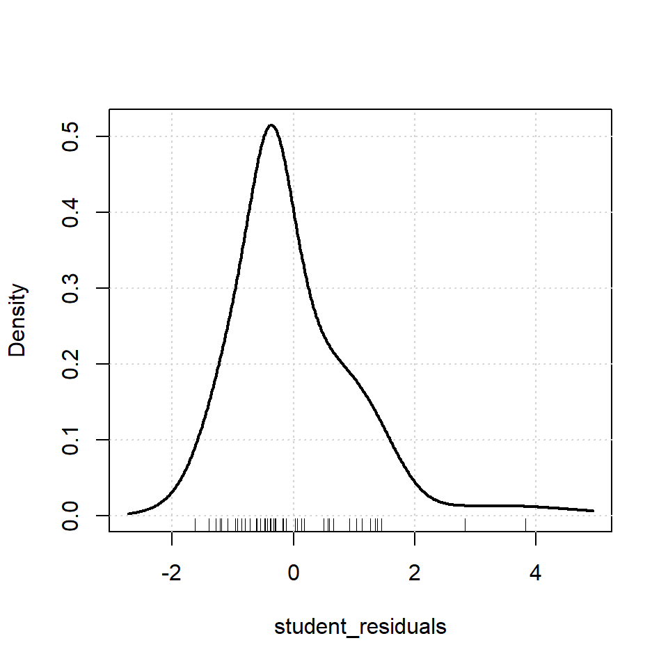

```r
student_residuals <- rstudent(m2)
# Density Plot of the Studentized residuals from Model 2
densityPlot(student_residuals)
```

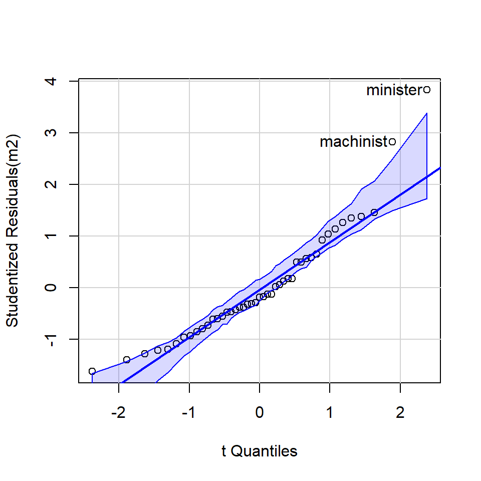

```
 minister machinist
        6        28
```

```r
# QQ Plot (against a t-distribution) of the residuals in Model 2
qqPlot(m2)
```

As we can see from the output above, the Model 2 seems to conform quite well to the normality of errors assumption needed for a linear regression model. The density plot of the t-residuals looks pretty close to a symmetric and normal distribution, perhaps with a bit of a long positive tail.

Similarly, the qq-plot shows that the studentized residuals fit pretty well the theoretical quantiles reflected in the 45-degree line. The fit is quite good overall, perhaps with some exceptions towards the very low and very high quantiles.

Overall, the normality of errors assumption does not seem to be a problem for Model 2.

#### B. Influence = outliers * leverage

The `outlierTest()` function tests for outliers in the regression. The `influenceIndexPlot()` function creates a graph that displays influence measures in index plots. The `avPlots()` function creates added variable plots, which allow you to visualize how influential data points might be affecting (or not) the estimated coefficients.

Using these (and/or other tools), using your preferred model from Question 2, are there any influential data points?

If the diagnostics suggest that there are influential points, does removing these influential points change the results of the analysis? Compare models using the `compareCoefs()` function. What do you conclude?

**Solution**

```r
outlierTest(m2)
```

```
         rstudent unadjusted p-value Bonferroni p
minister 3.829396         0.00045443      0.02045
```

As we can see from the results of the Bonferroni test above, there is 1 observation/occupation that can be considered as an outlier in the model. The Minister occupation. This can be due to the fact that it is an occupation that is also thought as being somewhat outside of the “market logic” and more into a spiritual domain, which may create different perceptions of prestige and required credentials.

To additionally test whether the Minister observation (or others) have an undue weight (influence) on the models point estimates, I will produce influence plots that contain the Cook distance.

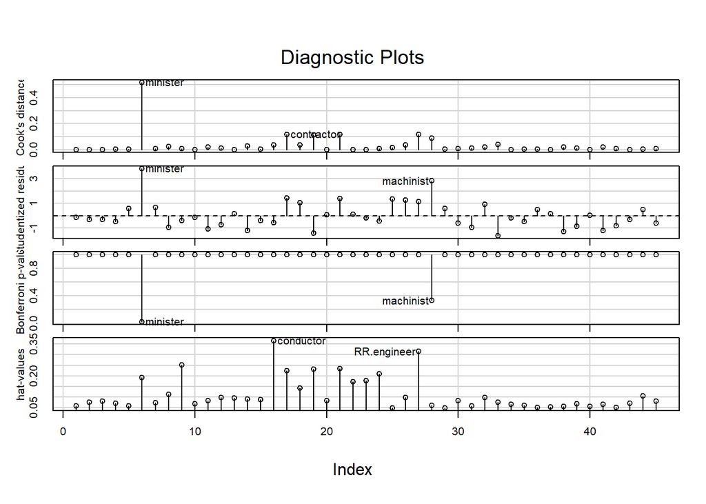

```r
influenceIndexPlot(m2)
```

As we can see from the plot above, the Minister occupation does appear to have high influence on the model, as reflected by the high Cook distance measure.

The Machinist occupation only stands out in terms of the Studentized Residual and the Bonferroni p-value (which feed off each other), but does not stand out in terms of the Cook distance or the Hat-values. As such, I will not consider the Machinist to be an influential data point. The same logic applies to the Conductor and RR engineer occupations, since they only stand out in terms of hat-value but not in Cook distance or Bonferroni outlier test.

**Based on the above, I will re-run the Model 2 excluding the Minister observation and compare the coefficients**

```r
duncan_data_m2a <- duncan_data %>%
                      filter(., rownames(duncan_data) != "minister")

m2a <- lm(prestige ~ education + income + type, data = duncan_data_m2a)
compareCoefs(m2, m2a, pvals = TRUE)
```

```
Calls:
1: lm(formula = prestige ~ education + income + type, data = duncan_data)
2: lm(formula = prestige ~ education + income + type, data =
  duncan_data_m2a)

            Model 1 Model 2
(Intercept)  -0.185  -1.630
SE            3.714   3.228
Pr(>|z|)     0.9603  0.6137

education    0.3453  0.2892
SE           0.1136  0.0992
Pr(>|z|)     0.0024  0.0035

income       0.5975  0.7181
SE           0.0894  0.0833
Pr(>|z|)    2.3e-11 < 2e-16

typewc       -14.66  -15.88
SE             6.11    5.28
Pr(>|z|)     0.0164  0.0027

typeprof      16.66   13.43
SE             6.99    6.10
Pr(>|z|)     0.0172  0.0276
```

From the table above, we can see that excluding the Minister occupation does result in changes in the magnitude of the coefficients of interest, but it does not affect their sign or the significance (at the p < 0.05 level) of the estimates. The coefficients that were statistically significant remain so, and vice-versa.

In conclusion, while the Minister occupation was an influential datapoint, its exclusion or inclusion does not meaningfully affect the general interpretation that we take from the model. The coefficients remain of the same sign, remain equally significant, and the change in magnitude of the coefficients does not appear to be too large. However, I would need to know more about the scale of the prestige variable (the outcome) to better assess what these magnitudes mean.

Because of the above, my prefered model remains the one that *includes* the minister occupation and all covariates (Model 2).

#### C. Non-linearity

Component-plus-residual plots allow for the detection of non-linearity in the partial relationship between each covariate and the outcome. These can be created using the `crPlots()` function.

For your preferred model, does it appear there is any nonlinearity? Explain.

**Solution**

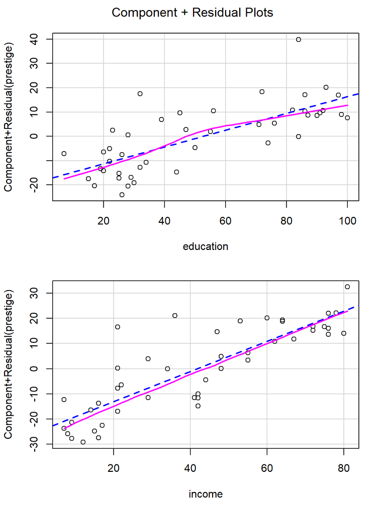

```r
crPlots(m2, terms = ~ education + income, layout = c(2,1))
```

The plots above do not show evidence of a non-linear relationship between the continuous predictors and the outcome of interest (prestige). The component + residual plots show the predicted values to hover around the expected linear relationship, without a clear pattern to suggest otherwise.

#### D. Heteroscedasticity

Non-constant error variance can be tested using the `ncvTest()` function.

Does it appear that this is a concern with this data? Explain

**Solution**

```r
ncvTest(m2)
```

```
Non-constant Variance Score Test
Variance formula: ~ fitted.values
Chisquare = 0.2430753, Df = 1, p = 0.62199
```

For the ncvTest, the null hypothesis is that there is a constant error variance. The alternate hypothesis is that there is NOT constant error variance (heteroskedasticity).

From the results above, we see that there is NO evidence to reject the null hypothesis (p-val = 0.62). As such, the test does NOT suggest the presence of heteroskedasticity, which is what we assume when fitting a regular OLS model. This is a good outcome!

### 4. Interpretation

Should the model above be used to answer a descriptive, explanatory, or predictive question? Explain your answer.

**Solution**

This model should **not** be used to answer explanatory/causal questions. We do not have enough background information/context/quasi-experimental setting to infer that the associations found in the model are causal relationships. At this stage, and based on the limited information we have, these associations could be masking ommited variables that are the underlying common cause of covariates and outcome (or otherwise related to them). Even assuming causality, it would still be unclear whether income causes prestige, or the other way around (reverse causality).

In sum, this model should not be used for causal inference purposes. It is too bare-bones for it at the moment.

Instead, it **should be used as an exploratory/descriptive model** that allows us to identify some associations and relationships between concepts of interest (and their respective operationalized variables). In this case, we can find descriptive associations between prestige-income and prestige-education, for example. These initial descriptions of the world will allow us to focus more specifically on these domains, ask further questions, and come up with further research designs that will result in future models that will potentially allow us to make informed causal inference arguments.